## The Giant Swiss Water Battery

#### Debosree Mukherjee

Nant de Drance, a “water battery” located in Switzerland began its operations in July and has [an energy storage capacity equivalent to 400,000 electric car batteries](https://www.cnn.com/2022/08/01/world/water-battery-switzerland-renewable-energy-climate-scn-hnk-spc-intl/index.html). It is a giant pumped storage hydropower plant and is believed to play a big role in Europe’s transition to renewable energy.

Wind and solar power create inconsistent power supply because of their dependency on the weather. Variable-speed pump turbine powered water batteries such as Nant de Drance stabilizes the electricity grid. The plant has reversible turbines and can quickly go from storing energy to providing electricity.

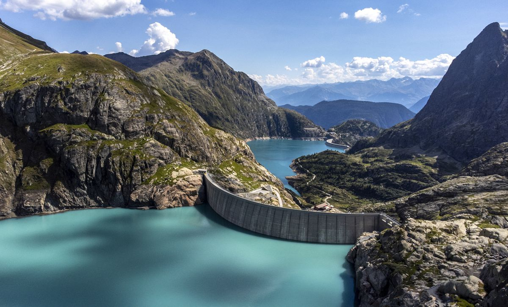

The cost to develop this plant was $2 billion and it took 14 years to complete. 17 kilometers of subterranean tunnels were excavated through the Alps. It has six turbines that are stored 600 meters below ground in a giant cavern. Two existing water reservoirs were repurposed for this project, and they now hold more water than 6,500 Olympic-sized swimming pools! The plant can store 20 million kWh of energy, enough to power 900,000 homes.

Europe is hoping to become the first climate-neutral continent and has the target for renewables to be 45% of its total energy supply by 2030. High-capacity storage facilities like Nant de Drance is essential to meet this goal. The plant has increased Switzerland’s installed energy capacity by 33%.